# Performing a Chi-Squared Test using Spreadsheet Software

Ryan Miller

The subsections below provide brief examples of how to use Google Sheets or Excel to perform each type of Chi-squared test that we’ve discussed in class.

$~$

### Goodness of fit testing

Shown below is the Alameda County jury pool example (see slide #13 from our Chi-squared notes)

**Step 1**: Type in the observed data:

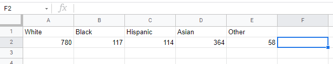

**Step 2**: Type in the expected proportions (ie: those in the null hypothesis)

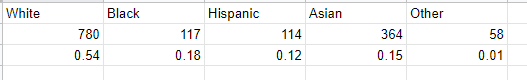

**Step 3**: Use the overall sample size and the expected proportions to find the expected counts

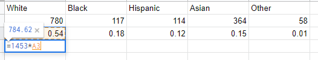

- Note: you can drag the formula to the right to auto-fill each category, but always double-check to make sure this worked as you intended.

**Step 4**: Find the Chi-squared contributions (ie: $\tfrac{(\text{observed} - \text{expected})^2}{\text{expected}}$)

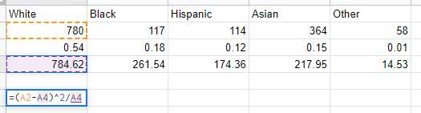

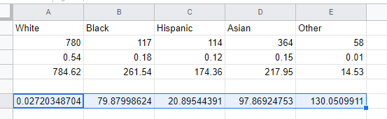

**Step 5**: Sum the Chi-squared contributions to get the $X^2$ test statistic

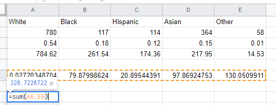

### Association

Shown below is the ACTN3 example (slides 16-21)

**Step 1**: Type in the observed data:

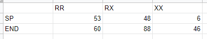

**Step 2**: Add the row and column totals:

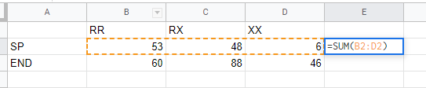

**Step 3**: Use these totals to find the expected table:

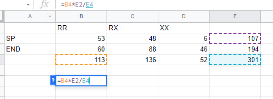

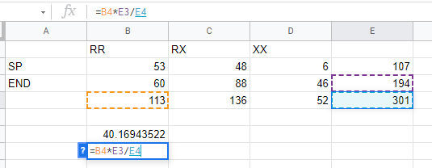

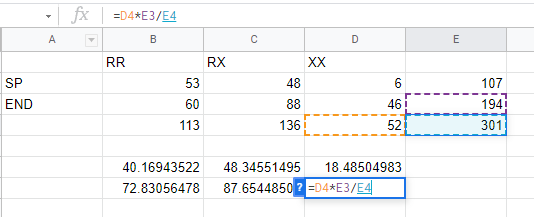

*Note*: unfortunately you *cannot* drag these formulas

**Step 4**: Find the Chi-squared contributions (ie: $\tfrac{(\text{observed} - \text{expected})^2}{\text{expected}}$)

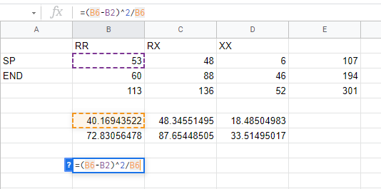

*Note*: you *can* drag these formulas

**Step 5**: Sum the Chi-squared contributions to get the $X^2$ test statistic

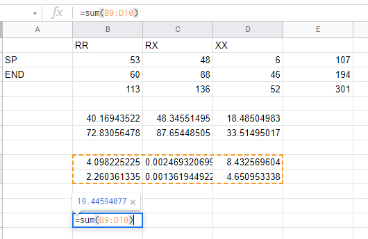